# Unit 6 Case Study - Real Time Location

## [1.6.1] K = 1 and K = 3

```r
#Predict using 3 nearest neighbors and 3 orientations
estXYk3_2 = predXY(newSignals = onlineSummary2[ , 6:11],
                 newAngles = onlineSummary2[ , 4],
                 offlineSummary2, numAngles = 3, k = 3)
#Predict using k = 3 and weighted average
estXYk3w_2 = predXY3_w(newSignals = onlineSummary2[ , 6:11],
                 newAngles = onlineSummary2[ , 4],
                 offlineSummary2, numAngles = 3, k = 3)
#Predict using 1 nearest neighbors and 3 orientations
estXYk1_2 = predXY(newSignals = onlineSummary2[ , 6:11],
                 newAngles = onlineSummary2[ , 4],
                 offlineSummary2, numAngles = 3, k = 1)
#Predict using k = 1 and weighted average
estXYk1w_2 = predXY_w(newSignals = onlineSummary2[ , 6:11],
                 newAngles = onlineSummary2[ , 4],
                 offlineSummary2, numAngles = 3, k = 1)
```

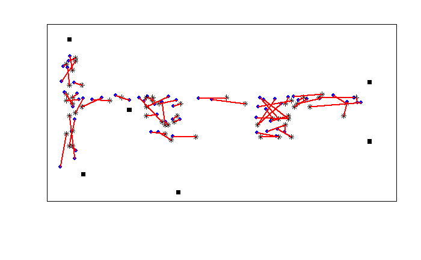

```r
trainPoints = offlineSummary2[ offlineSummary2$angle == 0 &
                              offlineSummary2$mac == "00:0f:a3:39:dd:cd" ,
                        c("posX", "posY")]
floorErrorMap(estXYk3_2, onlineSummary2[ , c("posX","posY")],
              trainPoints = trainPoints, AP = AP)
```

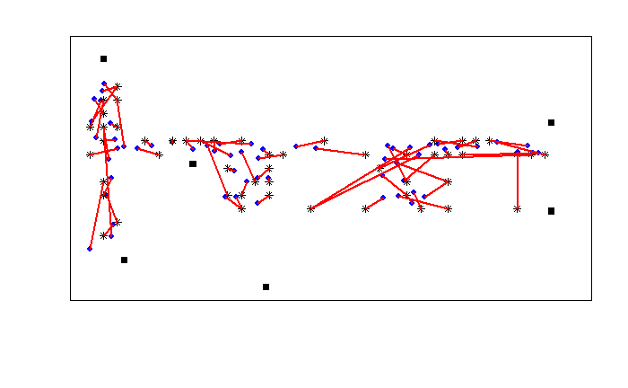

```r
floorErrorMap(estXYk1_2, onlineSummary2[ , c("posX","posY")],
              trainPoints = trainPoints, AP = AP)
```

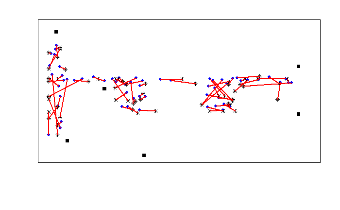

```r
floorErrorMap(estXYk3w_2, onlineSummary2[ , c("posX","posY")],
              trainPoints = trainPoints, AP = AP)
```

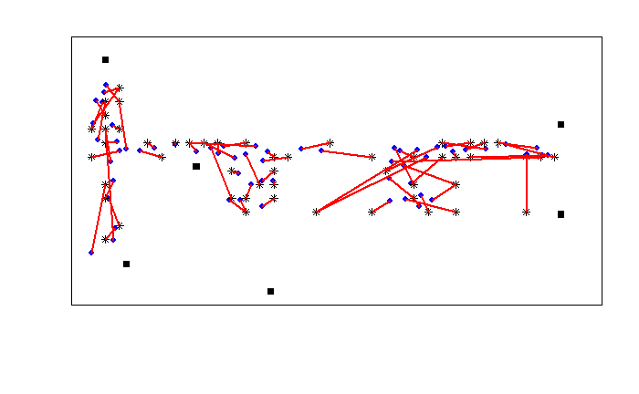

```r
floorErrorMap(estXYk1w_2, onlineSummary2[ , c("posX","posY")],
              trainPoints = trainPoints, AP = AP)
```

```r
actualXY = onlineSummary2[ , c("posX", "posY")]
sapply(list(estXYk1_2, estXYk3_2, estXYk1w_2, estXYk3w_2
            ), calcError, actualXY)
```

```
[1] 659.4003 306.7025 659.4003 445.4785
```

## [1.6.2] Cross-validation

```r
#Determine a number (v) of non-overlapping subsets of equal size
#Build a model for each subset using all the data except the selected subset
#Predict using the model for the selected subset
#Repeat for each subset and then aggregrate the prediction errors accross subsets
#v = Number of subsets
v = 11
permuteLocs = sample(unique(offlineSummary2$posXY))
permuteLocs = matrix(permuteLocs, ncol = v,
                     nrow = floor(length(permuteLocs)/v))
```

```
data length [166] is not a sub-multiple or multiple of the number of rows [15]
```

```r
onlineFold2 = subset(offlineSummary2, posXY %in% permuteLocs[ , 1])
offline = readData()
offline = offline[ offline$mac != "00:0f:a3:39:e1:c0", ]
offline$posXY = paste(offline$posX, offline$posY, sep = "-")
onlineCVSummary2 = reshapeSS(offline, keepVars = keepVars,
                            sampleAngle = TRUE)
onlineFold2 = subset(onlineCVSummary2,
                    posXY %in% permuteLocs[ , 1])
offlineFold2 = subset(offlineSummary2,
                     posXY %in% permuteLocs[ , -1])
estFold2 = predXY(newSignals = onlineFold2[ , 6:11],
                 newAngles = onlineFold2[ , 4],
                 offlineFold2, numAngles = 3, k = 3)
estFold2_w = predXY3_w(newSignals = onlineFold2[ , 6:11],
                 newAngles = onlineFold2[ , 4],
                 offlineFold2, numAngles = 3, k = 3)
actualFold = onlineFold[ , c("posX", "posY")]
calcError(estFold2, actualFold)
```

```
[1] 3507
```

```r
calcError(estFold2_w, actualFold)
```

```
[1] 3587.408
```

## [1.6.3] Choice of k

But are we using the best number of k?

```r
#Find the nearest neighbor estimates for each subset for k = 1, 2,...K
#Aggregate the errors over the number of subsets
#Should use k = 10 or 20 but taking too long to run
K = 10
err = rep(0, K)
for (j in 1:v) {
  onlineFold2 = subset(onlineCVSummary2,
                      posXY %in% permuteLocs[ , j])
  offlineFold2 = subset(offlineSummary2,
                       posXY %in% permuteLocs[ , -j])
  actualFold2 = onlineFold2[ , c("posX", "posY")]

  for (k in 1:K) {
    estFold2 = predXY(newSignals = onlineFold2[ , 6:11],
                     newAngles = onlineFold2[ , 4],
                     offlineFold2, numAngles = 3, k = k)
    err[k] = err[k] + calcError(estFold2, actualFold2)
  }
}
#Plot the results to find the best k
plot(y = err, x = (1:K),  type = "l", lwd= 2,
     ylim = c(1000, 2000),
     xlab = "Number of Neighbors",
     ylab = "Sum of Square Errors")
rmseMin = min(err)
kMin = which(err == rmseMin)[1]
segments(x0 = 0, x1 = kMin, y0 = rmseMin, col = gray(0.4),
         lty = 2, lwd = 2)
```

[figure not shown]

```r
segments(x0 = kMin, x1 = kMin, y0 = 1100,  y1 = rmseMin,
         col = grey(0.4), lty = 2, lwd = 2)
text(x = kMin - 2, y = rmseMin + 40,
     label = as.character(round(rmseMin)), col = grey(0.4))
```

```r
estXYk4_2 = predXY(newSignals = onlineSummary2[ , 6:11],
                 newAngles = onlineSummary2[ , 4],
                 offlineSummary2, numAngles = 3, k = 4)
calcError(estXYk4_2, actualXY)
```

```
[1] 301.5728
```

# [1.7] Results

Generally based on the results in the previous two sections, it appears as if the unweighted mean for predicting location performs better than the weighted mean. The least square error equals unweighted function as the weight nears zero.

```r
estXYk5 = predXY(newSignals = onlineSummary[ , 6:11],
                 newAngles = onlineSummary[ , 4],
                 offlineSummary, numAngles = 3, k = 5)
estXYk5_2 = predXY(newSignals = onlineSummary2[ , 6:11],
                 newAngles = onlineSummary2[ , 4],
                 offlineSummary2, numAngles = 3, k = 5)
estXYk5w = predXY5_w(newSignals = onlineSummary[ , 6:11],
                 newAngles = onlineSummary[ , 4],
                 offlineSummary, numAngles = 3, k = 5)
estXYk5w_2 = predXY5_w(newSignals = onlineSummary2[ , 6:11],
                 newAngles = onlineSummary2[ , 4],
                 offlineSummary2, numAngles = 3, k = 5)
sapply(list(estXYk5, estXYk5w, estXYk5_2, estXYk5w_2), calcError, actualXY)
```

```
[1] 275.5083 421.9367 275.5083 421.9367
```

# References

Nolan and Lang, Data Science in R, A Case Studies Approach, CRC Press